# Coordinating on-demand service supply and demand paper notes

Adam Spannbauer

2024-12-02

```r
library(tidyverse)
library(triangle)
library(patchwork)
library(plotly)

plot_shaded_normal <- function(mean, sd, p = 0.5) {
  shade_up_to_x <- qnorm(p, mean = mean, sd = sd)

  data_normal <- data.frame(
    x = seq(mean - 4 * sd, mean + 4 * sd, length.out = 300)
  ) |>
    mutate(y = dnorm(x, mean = mean, sd = sd))

  shaded_data_normal <- data_normal |>
    filter(x <= shade_up_to_x)

  ggplot(data_normal, aes(x = x, y = y)) +
    geom_line() +
    geom_area(
      data = shaded_data_normal,
      aes(x = x, y = y),
      fill = "#ff8800",
      alpha = 0.3
    ) +
    geom_vline(xintercept = shade_up_to_x)
}

plot_shaded_triangle <- function(a, b, c = (a + b) / 2, p = 0.5) {
  shade_up_to_x <- triangle::qtriangle(p, a = a, b = b, c = c)

  data_tri <- data.frame(
    x = seq(a, b, length.out = 300)
  ) |>
    mutate(y = triangle::dtriangle(x, a = a, b = b, c = c))

  shaded_data_tri <- data_tri |>
    filter(x <= shade_up_to_x)

  ggplot(data_tri, aes(x = x, y = y)) +
    geom_line() +
    geom_area(
      data = shaded_data_tri,
      aes(x = x, y = y),
      fill = "#ff8800",
      alpha = 0.3
    ) +
    geom_vline(xintercept = shade_up_to_x)
}

plot_shaded_unif <- function(a = 0, b = 1, p = 0.5) {
  shade_up_to_x <- qunif(p, min = a, max = b)

  data_unif <- data.frame(
    x = seq(a, b, length.out = 300)
  ) |>
    mutate(y = dunif(x, min = a, max = b))

  shaded_data_unif <- data_unif |>
    filter(x <= shade_up_to_x)

  ggplot(data_unif, aes(x = x, y = y)) +
    geom_line() +
    geom_area(
      data = shaded_data_unif,
      aes(x = x, y = y),
      fill = "#ff8800",
      alpha = 0.3
    ) +
    geom_vline(xintercept = shade_up_to_x)
}
```

Reading paper:

Bai, J., So, K. C., Tang, C. S., Chen, X., & Wang, H. (2019). Coordinating supply and demand on an on-demand service platform with impatient customers. Manufacturing & Service Operations Management, 21(3), 556-570. https://doi.org/10.1287/msom.2018.0707

# Notes

## General overview and goals

- Customers arrive randomly
- Each service consists of random amount of service units (e.g. travel distance)
  - Assumed any service can be rendered by any agent (maybe not true in reality where drivers cancel trips based on distance)
- Fixed price rate $p$ per service unit (e.g. dollars per kg)
- Fixed wage rate $w$ per service unit
- Payout ratio: $\frac{w}{p}$

No focus on surge pricing for ease of modeling and cites customer dissatisfaction if price jumps in short time span.

Assumed $p$ and $w$ are known to customers and agents in advance.

Goal of service platform is to set $p^*$ and $w^*$ to maximize average profit.

## Realized customer rate $\lambda$ and price rate $p$

### Setup

- Let $\lambda$ be the customer request rate with max amount of service in a time period is $\bar{\lambda}$
- Customer value per service unit is $v$ (heterogeneous with CDF $F(\cdot)$)
- For a customer with valuation $v$ and service request of $D$ units the surplus is $(v - p)D$
  - $D$ is assumed to be independent of customer-type $v$
  - expected value of service units will be modeled as $d = E(D)$
- Utility function of a customer can be modeled as $U(v) = (v - p)d - cW_q$
  - $v$ is value per service unit
  - $p$ is price per service unit
  - $d$ is expected value of service units
  - $c$ is cost of waiting
  - $W_q$ is expected wait time for service
- Realized customer request rate $\lambda$ is the percent of $\bar{\lambda}$ of customers who have $U(v) \ge 0$ for a given $p$
  - aka $\lambda = \text{Prob} \left\{ U(v) \ge 0 \right\} \cdot \bar{\lambda} \to \lambda = \text{Prob} \left\{ v \ge p + \frac{c}{d} W_q \right\} \cdot \bar{\lambda}$
  - steps
    - $(v-p)d-cW_q \ge 0$
    - $vd-pd-cW_q \ge 0$
    - $vd \ge pd-cW_q$
    - $v \ge p - \frac{c}{d}W_q$
- This probability is labeled $s$ (i.e. $s = \text{Prob} \left\{ v \ge p + \frac{c}{d} W_q \right\}$ and $\lambda = s \bar{\lambda}$) and represents the desired service rate. We can manipulate $p$ to decide what percentage of $\bar{\lambda}$ to target
- Since $v \sim F(\cdot)$ then the price rate satisfies $p = F^{-1} \left( 1 - \frac{\lambda}{\bar{\lambda}} \right) - \frac{c}{d} W_q$ (note this could be written $p = F^{-1} \left( 1 - s \right) - \frac{c}{d} W_q$ to show service rate more directly)
  - Steps
    - $\lambda = \text{Prob} \left\{ v \ge p + \frac{c}{d} W_q \right\} \cdot \bar{\lambda}$
    - $\lambda = \left[ 1 - F\left( p + \frac{c}{d} W_q \right) \right] \cdot \bar{\lambda}$
    - $\frac{\lambda}{\bar{\lambda}} = 1 - F\left( p + \frac{c}{d} W_q \right)$
    - $F\left( p + \frac{c}{d} W_q \right) = 1 - \frac{\lambda}{\bar{\lambda}}$
    - $p + \frac{c}{d} W_q = F^{-1}\left(1 - \frac{\lambda}{\bar{\lambda}}\right)$
    - $p = F^{-1}\left(1 - \frac{\lambda}{\bar{\lambda}}\right) - \frac{c}{d} W_q$ or $p = F^{-1}\left(1 - s\right) - \frac{c}{d} W_q$
  - Holding everything else constant
    - Price rate decreases as wait time ( $W_q$ ) increases
    - Price rate decreases as unit wait cost ( $c$ ) increases
    - Price rate increases as number of service units ( $d$ ) increases

### Final results

Price is prescribed as:

$$p = F^{-1}\left(1 - s\right) - \frac{c}{d} W_q = F^{-1}\left(1 -
\frac{\lambda}{\bar{\lambda}}\right) - \frac{c}{d} W_q$$

For given

- Service rate ( $s = \frac{\lambda}{\bar{\lambda}}$ )
  - $\lambda$ is requesting customers
  - $\bar{\lambda}$ is max potential requesting customers
- Wait time ( $W_q$ )
- Expected service units ( $d$ )
- Cost of wait per unit time ( $c$ )
- Inverse CDF of customer valuation of service per unit ( $v \sim F(\cdot)$ )

```r
# Price rate as a function of service level
price_rate <- function(lambda, lambda_bar, c, d, Wq, Finv = \(p) qunif(p = p, min = 0, max = 1)) {
  s <- lambda / lambda_bar
  Finv(1 - s) - (c / d) * Wq
}
```

#### How price varies with individual params

Holding all other factors constant and just manipulating the input shown on x axis.

These relationships are the similar in behavior regardless of choice of value distribution family ( $F(\cdot)$ ).

- If $c$ increases (and target service rate is the same), we charge less since the cost of waiting per unit of service $\frac{c}{d}$ increases (if we kept same price we would be over priced and we’d be below target service)
- If $d$ increases (and target service rate is the same), we charge more since the cost of waiting per unit of service $\frac{c}{d}$ decreases (if we kept same price we would be under priced and we’d be above target service rate)
- If $\lambda$ increases (aka target service rate increases), we charge less to mitigate the effects of waiting while maintaining value
- If $W_q$ increases, we charge less to mitigate the effects of waiting while maintaining value

These notes don’t reflect how $\lambda$ and $W_q$ are related (i.e. more requests would lead to more wait time assuming the same supply).

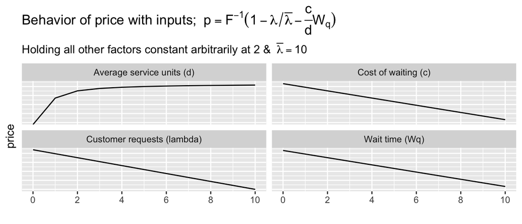

```r
ex_range <- 0:10

lambda_bar <- 10

lambda <- 2
c <- 2
d <- 2
Wq <- 2

# value dist
Finv <- \(p) qunif(p = p, min = 0, max = 1)


ex_lambda <- price_rate(ex_range, lambda_bar, ex_range, d, Wq, Finv)
ex_c <- price_rate(lambda, lambda_bar, ex_range, d, Wq, Finv)
ex_d <- price_rate(lambda, lambda_bar, c, ex_range, Wq, Finv)
ex_Wq <- price_rate(lambda, lambda_bar, c, d, ex_range, Finv)

func_behavior_df <- data.frame(
  ex_range = ex_range,
  lambda = ex_lambda,
  c = ex_c,
  d = ex_d,
  Wq = ex_Wq
)

func_behavior_df |>
  pivot_longer(-ex_range) |>
  mutate(name = ifelse(name == "c", "Cost of waiting (c)", name)) |>
  mutate(name = ifelse(name == "d", "Average service units (d)", name)) |>
  mutate(name = ifelse(name == "Wq", "Wait time (Wq)", name)) |>
  mutate(name = ifelse(name == "lambda", "Customer requests (lambda)", name)) |>
  ggplot(aes(x = ex_range, y = value)) +
  geom_line() +
  # geom_hline(yintercept = 0, linetype = "dotted") +
  facet_wrap(~name) +
  scale_x_continuous(breaks = seq(0, 10, 2)) +
  theme(
    axis.text.y = element_blank(), axis.ticks.y = element_blank()
  ) +
  labs(
    y = "price", x = "",
    title = bquote("Behavior of price with inputs; " ~
      p == F^
        {
          -1
        } * (1 - lambda / bar(lambda) - frac(c, d) * W[q])),
    subtitle = bquote("Holding all other factors constant arbitrarily at 2 & " ~ bar(lambda) == 10)
  )
```

#### Uniform distribution of value $v \sim F_{unif_{[0, 1]}}(\cdot)$

The paper will use a uniform distribution $[0, 1]$ to simplify analysis but insights extend to other families

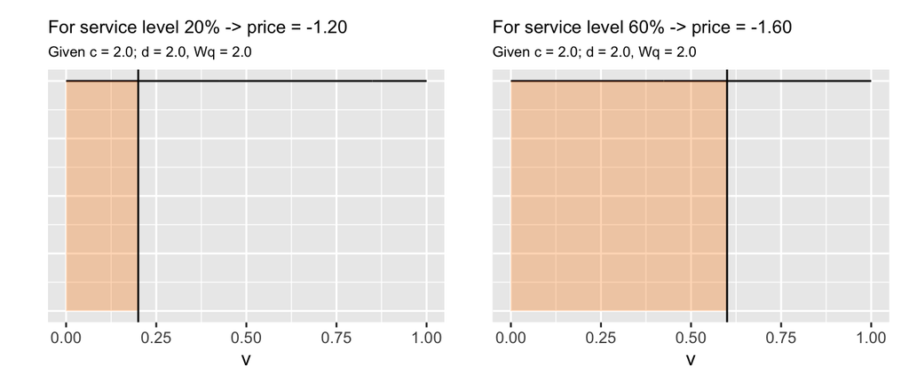

```r
c <- 2
d <- 2
Wq <- 2

# value dist (unifo) params
Finv <- \(p) qunif(p = p, min = 0, max = 1)

lambda <- 2
lambda_bar <- 10
s <- lambda / lambda_bar
p1 <- plot_shaded_unif(a = 0, b = 1, p = s) +
  labs(
    title = sprintf(
      "For service level %.0f%% -> price = %.2f ",
      s * 100, price_rate(lambda, lambda_bar, c, d, Wq, Finv)
    ),
    subtitle = sprintf("Given c = %.1f; d = %.1f, Wq = %.1f", c, d, Wq),
    x = "v",
    y = ""
  ) +
  theme(
    plot.title = element_text(size = 10),
    plot.subtitle = element_text(size = 8),
    axis.text.y = element_blank(),
    axis.ticks.y = element_blank()
  )


lambda <- 6
lambda_bar <- 10
s <- lambda / lambda_bar
p2 <- plot_shaded_unif(a = 0, b = 1, p = s) +
  labs(
    title = sprintf(
      "For service level %.0f%% -> price = %.2f ",
      s * 100, price_rate(lambda, lambda_bar, c, d, Wq, Finv)
    ),
    subtitle = sprintf("Given c = %.1f; d = %.1f, Wq = %.1f", c, d, Wq),
    x = "v",
    y = ""
  ) +
  theme(
    plot.title = element_text(size = 10),
    plot.subtitle = element_text(size = 8),
    axis.text.y = element_blank(),
    axis.ticks.y = element_blank()
  )


p1 + p2
```

#### Normal distribution of value $v \sim F_{normal}(\cdot)$

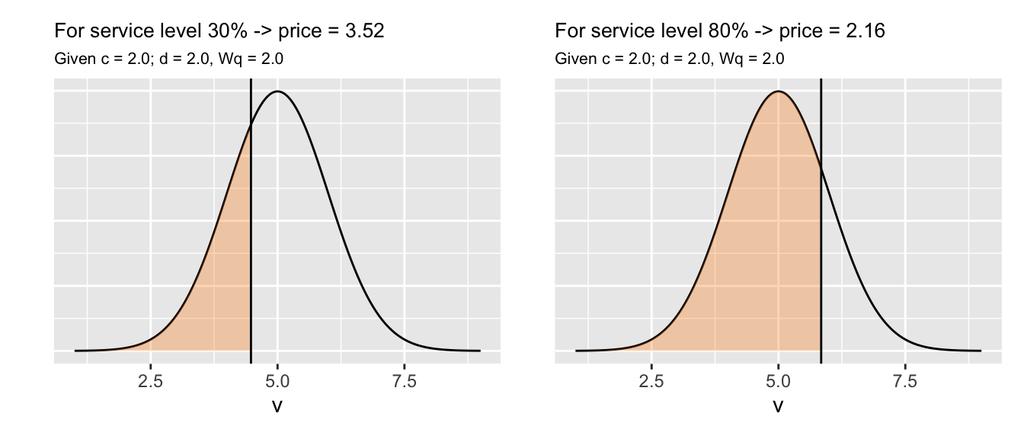

```r
c <- 2
d <- 2
Wq <- 2

# value dist (normal) params
mu <- 5
sd <- 1
Finv <- \(p) qnorm(p = p, mean = mu, sd = sd)

lambda <- 3
lambda_bar <- 10
s <- lambda / lambda_bar
p1 <- plot_shaded_normal(mean = mu, sd = sd, p = s) +
  labs(
    title = sprintf(
      "For service level %.0f%% -> price = %.2f ",
      s * 100, price_rate(lambda, lambda_bar, c, d, Wq, Finv)
    ),
    subtitle = sprintf("Given c = %.1f; d = %.1f, Wq = %.1f", c, d, Wq),
    x = "v",
    y = ""
  ) +
  theme(
    plot.title = element_text(size = 10),
    plot.subtitle = element_text(size = 8),
    axis.text.y = element_blank(),
    axis.ticks.y = element_blank()
  )

lambda <- 8
lambda_bar <- 10
s <- lambda / lambda_bar
p2 <- plot_shaded_normal(mean = mu, sd = sd, p = s) +
  labs(
    title = sprintf(
      "For service level %.0f%% -> price = %.2f ",
      s * 100, price_rate(lambda, lambda_bar, c, d, Wq, Finv)
    ),
    subtitle = sprintf("Given c = %.1f; d = %.1f, Wq = %.1f", c, d, Wq),
    x = "v",
    y = ""
  ) +
  theme(
    plot.title = element_text(size = 10),
    plot.subtitle = element_text(size = 8),
    axis.text.y = element_blank(),
    axis.ticks.y = element_blank()
  )

p1 + p2
```

## Realized providers $k$ and wage rate $w$

### Setup

- $K$ - maximum number of potential providers
- $k$ - realized number of providers for a given price $p$ and wage rate $w$ (wage as a percentage - $\alpha$ - of $p$)
  - $k \le K$
- $\mu$ - average service speed; so $\frac{\mu}{d}$ is service rate (i.e. average number of customers served per hour; $d$ is average service units requested)
- Given realized customers ( $\lambda$ ) and realized providers ( $k$ ), the utilization is $\frac{\lambda}{k \cdot (\mu / d)} = \frac{\lambda d}{k \mu}$
  - Aka $\rho = \frac{\lambda d}{k \mu}$ for $M/M/k$ queue
  - Similar to typical queueing $\rho = \frac{\lambda}{\mu}$, but incorporating $k$ providers and $d$ average service units
- Wage per unit time of a single provider is $w\mu$
- Average earning rate is $w\frac{\lambda d}{k}$
  - that is: single provider earning $w \mu$ times utilization $\frac{\lambda d}{k \mu}$
  - $w \mu \cdot \frac{\lambda d}{k \mu} = w\frac{\lambda d}{k}$
- Each provider has a “reservation earning rate” $r$ that has CDF $G(\cdot)$
  - i.e. they won’t average earning rate $\ge$ than reservation rate (aka $w\frac{\lambda d}{k} \ge r$ )
- $\beta$ will denote proportion of providers partipating
  - $\beta = \text{Prob} \left\{ r \le w(\lambda d / k) \right\} = G \left( w(\lambda d / k) \right)$
  - Also: $G^{-1}(\beta) = w \frac{\lambda d}{k}$
  - This means realized providers $k$ is $k = \beta K$

### Final results

Wage is prescribed as:

$$w = G^{-1}(\beta) \frac{k}{\lambda d} = G^{-1}(\frac{k}{K})
\frac{k}{\lambda d}$$

For given

- Participation rate ( $\beta = \frac{k}{K}$ )
  - $k$ is participating providers
  - $K$ is max potential participating providers
- Expected service units ( $d$ )
- Number of requesting customers ( $\lambda$ )
- Inverse CDF of provider reservation rate ( $r \sim G(\cdot)$ )

```r
# Wage rate as a function of provider participation rate
wage_rate <- function(k, K, lambda, d, Ginv = \(p) qunif(p = p, min = 0, max = 1)) {
  Ginv(k / K) * (k / (lambda * d))
}
```

#### How wage varies with individual params

Holding all other factors constant and just manipulating the input shown on x axis.

These relationships are the similar in behavior regardless of choice of reservation rate distribution family ( $G(\cdot)$ ).

- If $\lambda$ increases (and target participation rate is the same), we pay less since the average utilization of providers increases (more fares to go around)
- If $d$ increases (and target participation rate is the same), we pay less since the pay out per fare increases (more units of pay)
- If $k$ increases (aka target participation rate increases), we need to pay more to incentivize providers to enter

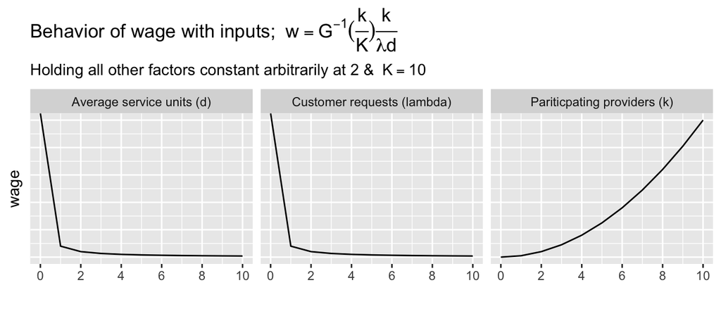

```r
ex_range <- 0:10

K <- 10

k <- 2
lambda <- 2
d <- 2

# reservation rate dist
Ginv <- \(p) qunif(p = p, min = 0, max = 1)

ex_k <- wage_rate(ex_range, K, lambda, d, Ginv)
ex_lambda <- wage_rate(k, K, ex_range, d, Ginv)
ex_d <- wage_rate(k, K, lambda, ex_range, Ginv)

func_behavior_df <- data.frame(
  ex_range = ex_range,
  k = ex_k,
  lambda = ex_lambda,
  d = ex_d
)

func_behavior_df |>
  pivot_longer(-ex_range) |>
  mutate(name = ifelse(name == "k", "Pariticpating providers (k)", name)) |>
  mutate(name = ifelse(name == "d", "Average service units (d)", name)) |>
  mutate(name = ifelse(name == "lambda", "Customer requests (lambda)", name)) |>
  ggplot(aes(x = ex_range, y = value)) +
  geom_line() +
  # geom_hline(yintercept = 0, linetype = "dotted") +
  facet_wrap(~name) +
  scale_x_continuous(breaks = seq(0, 10, 2)) +
  theme(
    axis.text.y = element_blank(), axis.ticks.y = element_blank()
  ) +
  labs(
    y = "wage", x = "",
    title = bquote("Behavior of wage with inputs; " ~
      w == G^
        {
          -1
        } * (frac(k, K)) * frac(k, lambda * d)),
    subtitle = bquote("Holding all other factors constant arbitrarily at 2 & " ~ K == 10)
  )
```

#### Uniform distribution of value $r \sim G_{unif_{[0, 1]}}(\cdot)$

The paper will use a uniform distribution $[0, 1]$ to simplify analysis but insights extend to other families

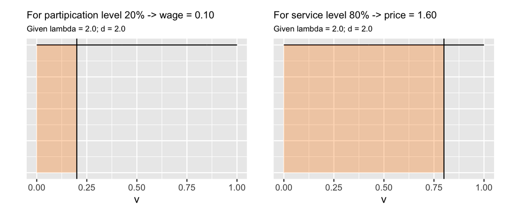

```r
lambda <- 2
d <- 2

# value dist (unifo) params
Ginv <- \(p) qunif(p = p, min = 0, max = 1)

k <- 2
K <- 10
beta <- k / K
p1 <- plot_shaded_unif(a = 0, b = 1, p = beta) +
  labs(
    title = sprintf(
      "For partipication level %.0f%% -> wage = %.2f ",
      beta * 100, wage_rate(k, K, lambda, d, Ginv)
    ),
    subtitle = sprintf("Given lambda = %.1f; d = %.1f", lambda, d),
    x = "v",
    y = ""
  ) +
  theme(
    plot.title = element_text(size = 10),
    plot.subtitle = element_text(size = 8),
    axis.text.y = element_blank(),
    axis.ticks.y = element_blank()
  )


k <- 8
K <- 10
beta <- k / K
p2 <- plot_shaded_unif(a = 0, b = 1, p = beta) +
  labs(
    title = sprintf(
      "For service level %.0f%% -> price = %.2f ",
      beta * 100, wage_rate(k, K, lambda, d, Ginv)
    ),
    subtitle = sprintf("Given lambda = %.1f; d = %.1f", lambda, d),
    x = "v",
    y = ""
  ) +
  theme(
    plot.title = element_text(size = 10),
    plot.subtitle = element_text(size = 8),
    axis.text.y = element_blank(),
    axis.ticks.y = element_blank()
  )


p1 + p2
```

## Objective: max profit

- Profit ( $\pi$ ) is $\pi = \lambda (p - w) d$
  - $\lambda$ - customer requests
  - $p$ - price rate per service unit
  - $w$ - wage rate per service unit
  - $d$ - average service units
- We can plug in the definitions of $p$ (in terms of service rate - $\lambda$) and $w$ (in terms of participating provider rate - $k$)
  - $\pi(k, \lambda) = \lambda d \left[ \left( F^{-1}\left(1 - \frac{\lambda}{\bar{\lambda}}\right) - \frac{c}{d} W_q \right) - \left( G^{-1}(\frac{k}{K}) \frac{k}{\lambda d} \right) \right]$
  - Or written with $s$ to denote request rate and $\beta$ to denote provider participation rate: $\max_{k, \lambda} \pi(k, \lambda) \equiv \lambda d \left[ \left( F^{-1}\left(1 - s\right) - \frac{c}{d} W_q \right) - \left( G^{-1}(\beta) \frac{k}{\lambda d} \right) \right]$
  - Subject to $\frac{\lambda d}{k \mu} < 1$ (i.e. the requests don’t outpace the service)
    - Note: maybe not a realistic constraint for peak event times, but maybe surge pricing and wait times can diminish request rate enough to hold
- We’ll use $\pi(k, \lambda)$ to find optimal supply $k^*$ and optimal demand $\lambda^*$, and in turn we can use $k^*$ and $\lambda^*$ to find optimal price $p^*$ and optimal wage rate $w^*$

## Base model

- Wage rate ( $w$ ) will be a proportion ( $\alpha$ ) of price rate ( $p$ ) - $w = \alpha p$
- Waiting time $W_q$ will be based on $M/M/k$ queue with arrival rate $\lambda$ and service rate $\frac{\mu}{d}$
  - $W_q = \frac{1}{1 + \left( \frac{k! (1 - \rho)}{k^k \rho^k} \right) \sum_{i=0}^{k-1} \frac{k^i \rho^i}{i!}} \left[ \frac{\rho}{\lambda (1 - \rho)} \right]$
  - Where $\rho = \frac{\lambda d}{k \mu}$ is system utilization with $\rho < 1$
- For simplicity in base model:
  - The distribution of $v$ (so far referred to as $F(\cdot)$ ) and $r$ (so far referred to as $G(\cdot)$ ) will both be modeled as uniform on range $[0, 1]$. This means we can drop out mention of them from current model.
    - $p = F^{-1}\left(1 - \frac{\lambda}{\bar{\lambda}}\right) - \frac{c}{d} W_q$ becomes $p = \left(1 - \frac{\lambda}{\bar{\lambda}}\right) - \frac{c}{d} W_q$
    - $w = G^{-1}(\frac{k}{K}) \frac{k}{\lambda d}$ becomes $w = \frac{k}{K} \cdot \frac{k}{\lambda d} = \frac{k^2}{K \lambda d}$
    - $\max_{k, \lambda} \pi(k, \lambda) = \lambda d (p - w) = \lambda d \left[ \left( F^{-1}\left(1 - s\right) - \frac{c}{d} W_q \right) - \left( G^{-1}(\beta) \frac{k}{\lambda d} \right) \right]$ becomes $\max_{k, \lambda} \pi(k, \lambda) = \lambda d (p - w) = \lambda d \left[ \left( \left(1 - s \right) - \frac{c}{d} W_q \right) - \left( \frac{k^2}{K \lambda d} \right) \right]$
  - Wage rate is $\alpha$ proportion of $p$ : $w = \alpha p \to \frac{w}{\alpha} = p$ ; avoid direct $p$ formulation since it becomes way messier when incorporating Wait time formulation
    - $\max_{k, \lambda} \pi(k, \lambda) = \lambda d (p - w) = \lambda d \left( \frac{w}{\alpha} - w \right)$
    - Incorporating definition of $w = \frac{k^2}{K \lambda d}$ we can write as $\max_{k, \lambda} \pi(k, \lambda) = \lambda d \left( \frac{k^2}{K \lambda d \alpha} - \frac{k^2}{K \lambda d} \right) = \frac{k^2}{K \alpha} - \frac{k^2}{K} = \frac{k^2 - k^2 \alpha}{K \alpha} = \frac{k^2 (1 - \alpha)}{K \alpha}$
    - Pretty clear to see we want to maximize number of participating providers $k$
  - This is subject to constraints
    - $\frac{\lambda d}{k \mu} < 1$
    - $w = \alpha p$ which can be written as (still avoiding writing out $W_q$ here; see def above)
      - $\frac{k^2}{K \lambda d} = \alpha \left[ \left(1 - \frac{\lambda}{\bar{\lambda}}\right) - \frac{c}{d} W_q \right]$
      - This implies $k^2 = {K \lambda d}\alpha \left[ \left(1 - \frac{\lambda}{\bar{\lambda}}\right) - \frac{c}{d} W_q \right]$

```r
exact_wait_time_ <- function(k, lambda, mu, d) {
  # $$
  # W_q = \frac{1}{1 + \left( \frac{k! (1 - \rho)}{k^k \rho^k} \right) \sum_{i=0}^{k-1} \frac{k^i \rho^i}{i!}} \left[ \frac{\rho}{\lambda (1 - \rho)} \right]
  # $$

  # Calculate rho (system utilization)
  rho <- (lambda * d) / (k * mu)
  stopifnot(rho < 1)

  # First fraction term
  # ... Denominator term 1
  ## scalar to adjust probs of term 2
  term1 <- (factorial(k) * (1 - rho)) / (k^k * rho^k)

  # ... Denominator term 2
  ## each term in summation is prob of i servers busy
  i <- 0:(k - 1)
  term2 <- sum((k^i * rho^i) / factorial(i))

  # Full formula for Wq
  wait_time <- 1 / (1 + term1 * term2) * (rho / (lambda * (1 - rho)))
  return(wait_time)
}

exact_wait_time <- Vectorize(exact_wait_time_, c("k", "lambda", "mu", "d"))

prob_queue_len <- function(i, k, lambda, mu, d) {
  rho <- (lambda * d) / (k * mu)

  n <- 0:(k - 1)
  p_0 <- 1 / (sum(rho^n / factorial(n)) + (rho^k / factorial(k)) * (1 / (1 - rho)))

  if (i == 0) {
    p_i <- p_0
  } else if (i < k) {
    p_i <- (rho^i / factorial(i)) * p_0
  } else {
    p_i <- (rho^i / (factorial(k) * k^(i - k))) * p_0
  }

  return(p_i)
}

queue_len_probs <- function(k, lambda, mu, d) {
  probs <- c()
  i_vals <- 0:(k + 10)
  for (i in i_vals) {
    p_i <- prob_queue_len(i, k, lambda, mu, d)
    probs[i + 1] <- p_i
  }

  return(data.frame(len = i_vals, prob = probs))
}

check_rho_constraint <- function(lambda, d, k, mu) {
  rho <- (lambda * d) / (k * mu)

  return(rho < 1)
}

check_fixed_payout_constraint <- function(
    k, K, lambda, lambda_bar,
    c, d,
    mu,
    alpha,
    tolerance = 0.01) {
  v1 <- k^2

  Wq <- exact_wait_time(k, lambda, mu, d)
  v2 <- K * lambda * d * alpha * ((1 - (lambda / lambda_bar)) - (c / d) * Wq)

  return(isTRUE(all.equal(v1, v2, tolerance = tolerance)))
}

profit_function <- function(
    k, K, lambda, lambda_bar,
    c, d,
    mu,
    alpha,
    Finv = \(p) qunif(p, min = 0, max = 1),
    Ginv = \(p) qunif(p, min = 0, max = 1)) {
  meets_rho_constraint <- check_rho_constraint(lambda, d, k, mu)

  if (!meets_rho_constraint) {
    return(list(
      meets_rho_constraint = FALSE,
      meets_fixed_payout_constraint = FALSE
    ))
  }

  meets_fixed_payout_constraint <- check_fixed_payout_constraint(k, K, lambda, lambda_bar, c, d, mu, alpha)

  if (!meets_fixed_payout_constraint) {
    return(list(
      meets_rho_constraint = TRUE,
      meets_fixed_payout_constraint = FALSE
    ))
  }

  Wq <- exact_wait_time(k, lambda, mu, d)

  price <- price_rate(lambda, lambda_bar, c, d, Wq, Finv)
  wage <- wage_rate(k, K, lambda, d, Ginv)

  profit <- (k^2 * (1 - alpha)) / (K * alpha)

  list(
    k = k,
    K = K,
    lambda = lambda,
    lambda_bar = lambda_bar,
    c = c,
    d = d,
    mu = mu,
    rho = (lambda * d) / (k * mu),
    alpha = alpha,
    Wq = Wq,
    Lq = lambda * Wq,
    queue_len_dist = queue_len_probs(k, lambda, mu, d),
    price = price,
    wage = wage,
    profit = profit,
    meets_rho_constraint = meets_rho_constraint,
    meets_fixed_payout_constraint = meets_fixed_payout_constraint
  )
}

display_results <- function(res) {
  display_res <- res[c("k", "K", "lambda", "lambda_bar", "rho", "Wq", "price", "wage", "alpha", "profit")]

  display_res |>
    as.data.frame() |>
    t() |>
    as.data.frame() |>
    rownames_to_column() |>
    set_names(c("Param", "Value")) |>
    mutate(Value = as.numeric(sprintf("%.3f", Value)))
}
```

Here is the results for row 1 of Table 1 to show my formulation matches.

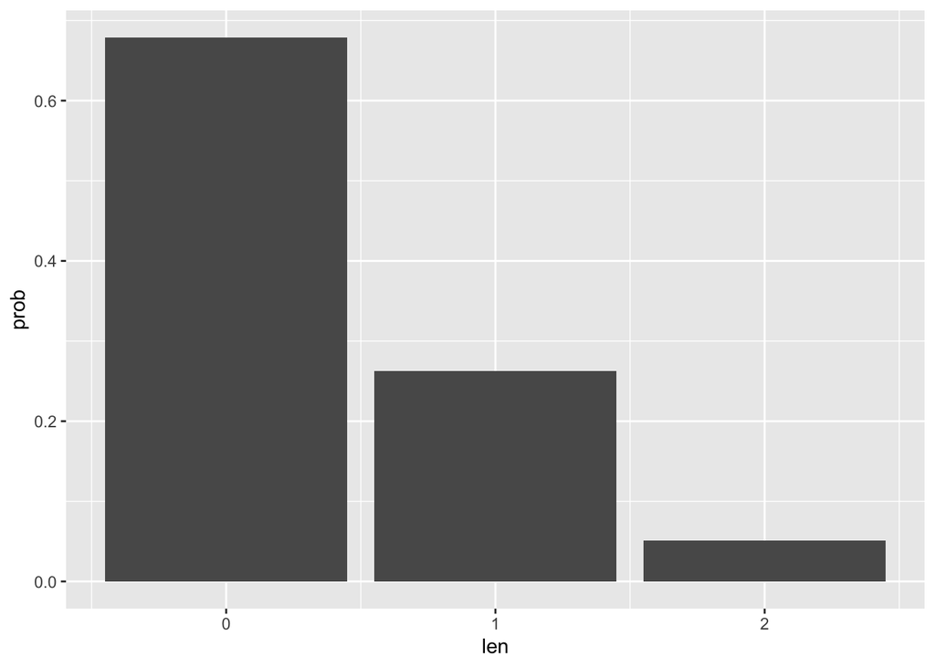

```r
res <- profit_function(k = 7, K = 50, lambda = 2.71, lambda_bar = 10, c = 1, d = 1, mu = 1, alpha = 0.5)

res$queue_len_dist |>
  filter(prob > 0.01) |>
  ggplot(aes(x = len, y = prob)) +
  geom_bar(stat = "identity")
```

```r
display_results(res)
```

| Param | Value |
| --- | --- |
| k | 7.000 |
| K | 50.000 |
| lambda | 2.710 |
| lambda_bar | 10.000 |
| rho | 0.387 |
| Wq | 0.005 |
| price | 0.724 |
| wage | 0.362 |
| alpha | 0.500 |
| profit | 0.980 |

Interestingly, and unreported by the paper. This is not a unique solution. Their Table 1 seems to prefer a solution with higher price and lower wait times.

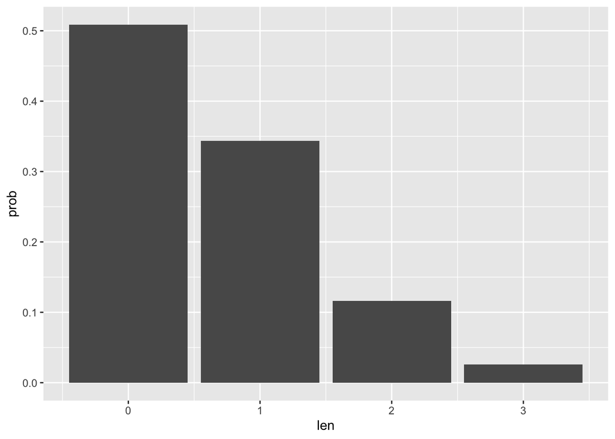

```r
res <- profit_function(k = 7, K = 50, lambda = 4.73, lambda_bar = 10, c = 1, d = 1, mu = 1, alpha = 0.5)

res$queue_len_dist |>
  filter(prob > 0.01) |>
  ggplot(aes(x = len, y = prob)) +
  geom_bar(stat = "identity")
```

```r
display_results(res)
```

| Param | Value |
| --- | --- |
| k | 7.000 |
| K | 50.000 |
| lambda | 4.730 |
| lambda_bar | 10.000 |
| rho | 0.676 |
| Wq | 0.116 |
| price | 0.411 |
| wage | 0.207 |
| alpha | 0.500 |
| profit | 0.980 |

### Examples searching for max profit

My formulation matches paper results, but to save time I’ve used a lower precision. Because of this, my optimal values for lambda will be off from paper table by decimal amounts.

```r
find_optimal_k_and_lambda <- function(
    K, lambda_bar, c, d, mu, alpha,
    Finv = \(p) qunif(p, min = 0, max = 1),
    Ginv = \(p) qunif(p, min = 0, max = 1),
    prefer_smaller_price = TRUE,
    k_step = 1,
    lambda_step = 0.01,
    tied_profit_tolerance = 0.001) {
  best_outcome <- NULL

  possible_k <- seq(1, K, by = k_step)

  # if (interactive()) {
  #   n_iter <- length(possible_k) * length(possible_lambda)
  #   pb <- txtProgressBar(min = 0, max = n_iter, style = 3)
  #   progress <- 0
  # }

  for (k in possible_k) {
    possible_lambda <- seq(lambda_step, k, by = lambda_step)
    for (lambda in possible_lambda) {
      res <- profit_function(
        k = k, K = K,
        lambda = lambda, lambda_bar = lambda_bar,
        c = c, d = d,
        mu = mu,
        alpha = alpha,
        Finv = Finv, Ginv = Ginv
      )

      if (res$meets_rho_constraint & res$meets_fixed_payout_constraint) {
        if (is.null(best_outcome)) {
          best_outcome <- res
          next
        }

        if (res$profit > best_outcome$profit) {
          best_outcome <- res
          next
        }

        # if profit is tied with best (within a tolerance)
        if (isTRUE(all.equal(res$profit, best_outcome$profit, tolerance = tied_profit_tolerance))) {
          if (prefer_smaller_price & res$price < best_outcome$price) {
            best_outcome <- res
          } else if (!prefer_smaller_price & res$price > best_outcome$price) {
            best_outcome <- res
          }
        }
      }

      # if (interactive()) {
      #   progress <- progress + 1
      #   setTxtProgressBar(pb, progress)
      # }
    }
  }

  # if (interactive()) {
  #   close(pb)
  # }
  return(best_outcome)
}
```

Here is the results for row 1 of Table 1 to show my formulation can find the same solution, but with a lack of precision.

```r
res <- find_optimal_k_and_lambda(
  K = 50,
  lambda_bar = 10,
  c = 1,
  d = 1,
  mu = 1,
  alpha = 0.5,
  prefer_smaller_price = FALSE
)

display_results(res)
```

| Param | Value |
| --- | --- |
| k | 7.000 |
| K | 50.000 |
| lambda | 2.670 |
| lambda_bar | 10.000 |
| rho | 0.381 |
| Wq | 0.005 |
| price | 0.728 |
| wage | 0.367 |
| alpha | 0.500 |
| profit | 0.980 |

```r
res <- find_optimal_k_and_lambda(
  K = 50,
  lambda_bar = 10,
  c = 1,
  d = 1,
  mu = 1,
  alpha = 0.5,
  prefer_smaller_price = TRUE
)

display_results(res)
```

| Param | Value |
| --- | --- |
| k | 7.000 |
| K | 50.000 |
| lambda | 4.730 |
| lambda_bar | 10.000 |
| rho | 0.676 |
| Wq | 0.116 |
| price | 0.411 |
| wage | 0.207 |
| alpha | 0.500 |
| profit | 0.980 |

### How inputs affect shape

#### $\alpha$ - wage rate percentage of price

##### Preferring higher prices

```r
all_res <- list()
i <- 0
for (alpha in seq(0.1, 0.9, 0.1)) {
  i <- i + 1

  res <- find_optimal_k_and_lambda(
    K = 50,
    lambda_bar = 10,
    c = 1,
    d = 1,
    mu = 1,
    alpha = alpha,
    prefer_smaller_price = FALSE
  )
  res$queue_len_dist <- NULL
  all_res[[i]] <- res
}

res_df <- do.call(rbind, lapply(all_res, as.data.frame))

res_df
```

| k | K | lambda | lambda_bar | c | d | mu | rho | alpha | Wq | Lq | price | wage | profit | meets_rho_constraint | meets_fixed_payout_constraint |
| --- | --- | --- | --- | --- | --- | --- | --- | --- | --- | --- | --- | --- | --- | --- | --- |
| 3 | 50 | 1.07 | 10 | 1 | 1 | 1 | 0.3566667 | 0.2 | 0.0555573621 | 0.059446377 | 0.8374426 | 0.1682243 | 0.7200000 | TRUE | TRUE |
| 5 | 50 | 2.20 | 10 | 1 | 1 | 1 | 0.4400000 | 0.3 | 0.0299744981 | 0.065943896 | 0.7500255 | 0.2272727 | 1.1666667 | TRUE | TRUE |
| 6 | 50 | 2.37 | 10 | 1 | 1 | 1 | 0.3950000 | 0.4 | 0.0104334038 | 0.024727167 | 0.7525666 | 0.3037975 | 1.0800000 | TRUE | TRUE |
| 7 | 50 | 2.67 | 10 | 1 | 1 | 1 | 0.3814286 | 0.5 | 0.0049527195 | 0.013223761 | 0.7280473 | 0.3670412 | 0.9800000 | TRUE | TRUE |
| 8 | 50 | 3.06 | 10 | 1 | 1 | 1 | 0.3825000 | 0.6 | 0.0029269470 | 0.008956458 | 0.6910731 | 0.4183007 | 0.8533333 | TRUE | TRUE |
| 9 | 50 | 3.59 | 10 | 1 | 1 | 1 | 0.3988889 | 0.7 | 0.0023139919 | 0.008307231 | 0.6386860 | 0.4512535 | 0.6942857 | TRUE | TRUE |
| 9 | 50 | 2.78 | 10 | 1 | 1 | 1 | 0.3088889 | 0.8 | 0.0003943717 | 0.001096353 | 0.7216056 | 0.5827338 | 0.4050000 | TRUE | TRUE |
| 10 | 50 | 3.28 | 10 | 1 | 1 | 1 | 0.3280000 | 0.9 | 0.0003309009 | 0.001085355 | 0.6716691 | 0.6097561 | 0.2222222 | TRUE | TRUE |

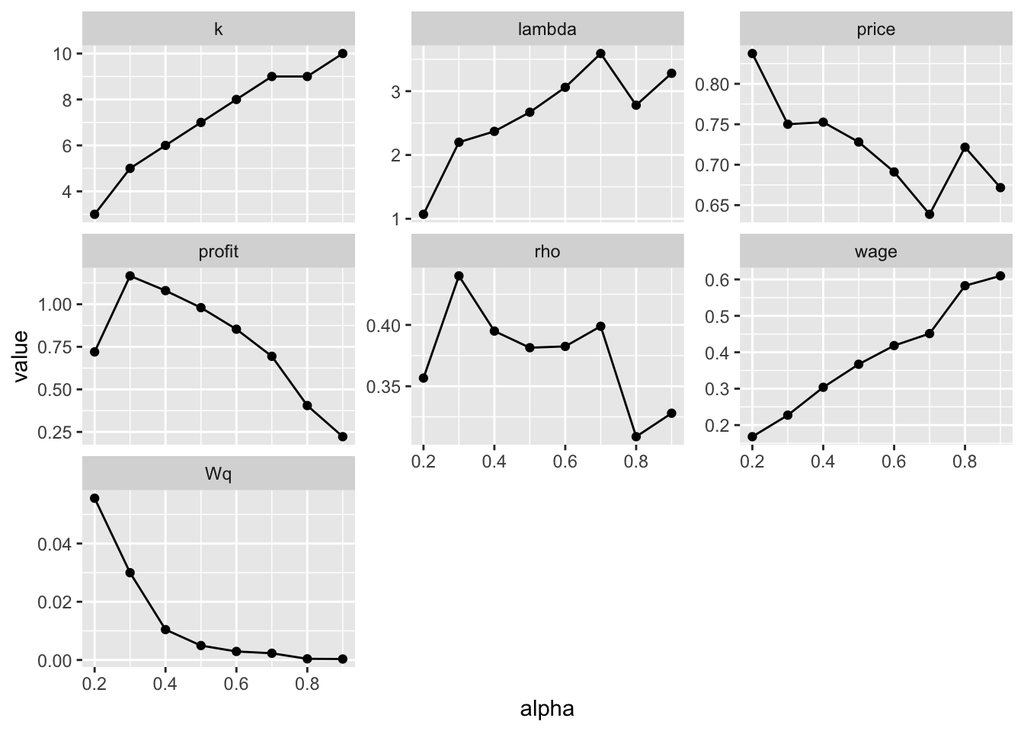

```r
res_df |>
  select(k, lambda, rho, alpha, Wq, price, wage, profit) |>
  pivot_longer(-alpha) |>
  ggplot(aes(x = alpha, y = value)) +
  geom_line() +
  geom_point() +
  facet_wrap(~name, scales = "free_y")
```

##### Preferring lower prices

```r
all_res <- list()
i <- 0
for (alpha in seq(0.1, 0.9, 0.1)) {
  i <- i + 1

  res <- find_optimal_k_and_lambda(
    K = 50,
    lambda_bar = 10,
    c = 1,
    d = 1,
    mu = 1,
    alpha = alpha,
    prefer_smaller_price = TRUE
  )
  res$queue_len_dist <- NULL
  all_res[[i]] <- res
}

res_df <- do.call(rbind, lapply(all_res, as.data.frame))

res_df
```

| k | K | lambda | lambda_bar | c | d | mu | rho | alpha | Wq | Lq | price | wage | profit | meets_rho_constraint | meets_fixed_payout_constraint |
| --- | --- | --- | --- | --- | --- | --- | --- | --- | --- | --- | --- | --- | --- | --- | --- |
| 3 | 50 | 1.86 | 10 | 1 | 1 | 1 | 0.6200000 | 0.2 | 0.33400853 | 0.6212559 | 0.4799915 | 0.09677419 | 0.7200000 | TRUE | TRUE |
| 5 | 50 | 3.22 | 10 | 1 | 1 | 1 | 0.6440000 | 0.3 | 0.16523107 | 0.5320440 | 0.5127689 | 0.15527950 | 1.1666667 | TRUE | TRUE |
| 6 | 50 | 4.06 | 10 | 1 | 1 | 1 | 0.6766667 | 0.4 | 0.15444724 | 0.6270558 | 0.4395528 | 0.17733990 | 1.0800000 | TRUE | TRUE |
| 7 | 50 | 4.73 | 10 | 1 | 1 | 1 | 0.6757143 | 0.5 | 0.11597809 | 0.5485764 | 0.4110219 | 0.20718816 | 0.9800000 | TRUE | TRUE |
| 8 | 50 | 5.22 | 10 | 1 | 1 | 1 | 0.6525000 | 0.6 | 0.07251098 | 0.3785073 | 0.4054890 | 0.24521073 | 0.8533333 | TRUE | TRUE |
| 9 | 50 | 5.44 | 10 | 1 | 1 | 1 | 0.6044444 | 0.7 | 0.03455120 | 0.1879585 | 0.4214488 | 0.29779412 | 0.6942857 | TRUE | TRUE |
| 9 | 50 | 6.00 | 10 | 1 | 1 | 1 | 0.6666667 | 0.8 | 0.06532697 | 0.3919618 | 0.3346730 | 0.27000000 | 0.4050000 | TRUE | TRUE |
| 10 | 50 | 6.11 | 10 | 1 | 1 | 1 | 0.6110000 | 0.9 | 0.02868175 | 0.1752455 | 0.3603183 | 0.32733224 | 0.2222222 | TRUE | TRUE |

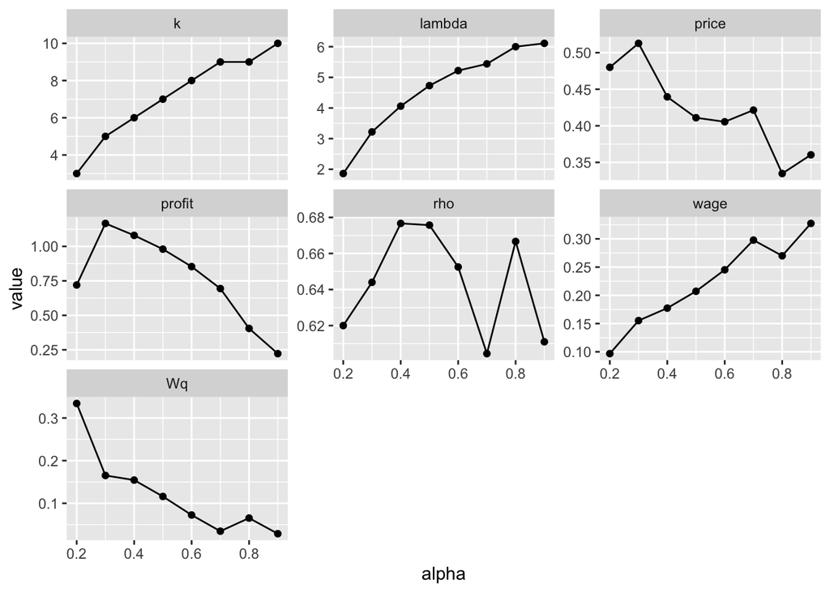

```r
res_df |>
  select(k, lambda, rho, alpha, Wq, price, wage, profit) |>
  pivot_longer(-alpha) |>
  ggplot(aes(x = alpha, y = value)) +
  geom_line() +
  geom_point() +
  facet_wrap(~name, scales = "free_y")
```

#### $\bar{\lambda}$ - max requests

##### Preferring higher prices

```r
all_res <- list()
i <- 0
for (lambda_bar in seq(10, 100, 10)) {
  i <- i + 1

  res <- find_optimal_k_and_lambda(
    K = 50,
    lambda_bar = lambda_bar,
    c = 1,
    d = 1,
    mu = 1,
    alpha = 0.5,
    prefer_smaller_price = FALSE
  )
  res$queue_len_dist <- NULL
  all_res[[i]] <- res
}

res_df <- do.call(rbind, lapply(all_res, as.data.frame))

res_df
```

| k | K | lambda | lambda_bar | c | d | mu | rho | alpha | Wq | Lq | price | wage | profit | meets_rho_constraint | meets_fixed_payout_constraint |
| --- | --- | --- | --- | --- | --- | --- | --- | --- | --- | --- | --- | --- | --- | --- | --- |
| 7 | 50 | 2.67 | 10 | 1 | 1 | 1 | 0.3814286 | 0.5 | 0.004952719 | 0.01322376 | 0.7280473 | 0.3670412 | 0.98 | TRUE | TRUE |
| 10 | 50 | 5.66 | 20 | 1 | 1 | 1 | 0.5660000 | 0.5 | 0.016985863 | 0.09613999 | 0.7000141 | 0.3533569 | 2.00 | TRUE | TRUE |
| 11 | 50 | 6.10 | 30 | 1 | 1 | 1 | 0.5545455 | 0.5 | 0.011112640 | 0.06778710 | 0.7855540 | 0.3967213 | 2.42 | TRUE | TRUE |
| 12 | 50 | 7.03 | 40 | 1 | 1 | 1 | 0.5858333 | 0.5 | 0.012943902 | 0.09099563 | 0.8113061 | 0.4096728 | 2.88 | TRUE | TRUE |
| 13 | 50 | 8.18 | 50 | 1 | 1 | 1 | 0.6292308 | 0.5 | 0.018190028 | 0.14879443 | 0.8182100 | 0.4132029 | 3.38 | TRUE | TRUE |
| 14 | 50 | 9.59 | 60 | 1 | 1 | 1 | 0.6850000 | 0.5 | 0.030486637 | 0.29236685 | 0.8096800 | 0.4087591 | 3.92 | TRUE | TRUE |
| 14 | 50 | 9.15 | 70 | 1 | 1 | 1 | 0.6535714 | 0.5 | 0.020504231 | 0.18761372 | 0.8487815 | 0.4284153 | 3.92 | TRUE | TRUE |
| 15 | 50 | 10.81 | 80 | 1 | 1 | 1 | 0.7206667 | 0.5 | 0.040603549 | 0.43892436 | 0.8242715 | 0.4162812 | 4.50 | TRUE | TRUE |
| 15 | 50 | 10.43 | 90 | 1 | 1 | 1 | 0.6953333 | 0.5 | 0.029567657 | 0.30839066 | 0.8545435 | 0.4314477 | 4.50 | TRUE | TRUE |
| 15 | 50 | 10.20 | 100 | 1 | 1 | 1 | 0.6800000 | 0.5 | 0.024292642 | 0.24778495 | 0.8737074 | 0.4411765 | 4.50 | TRUE | TRUE |

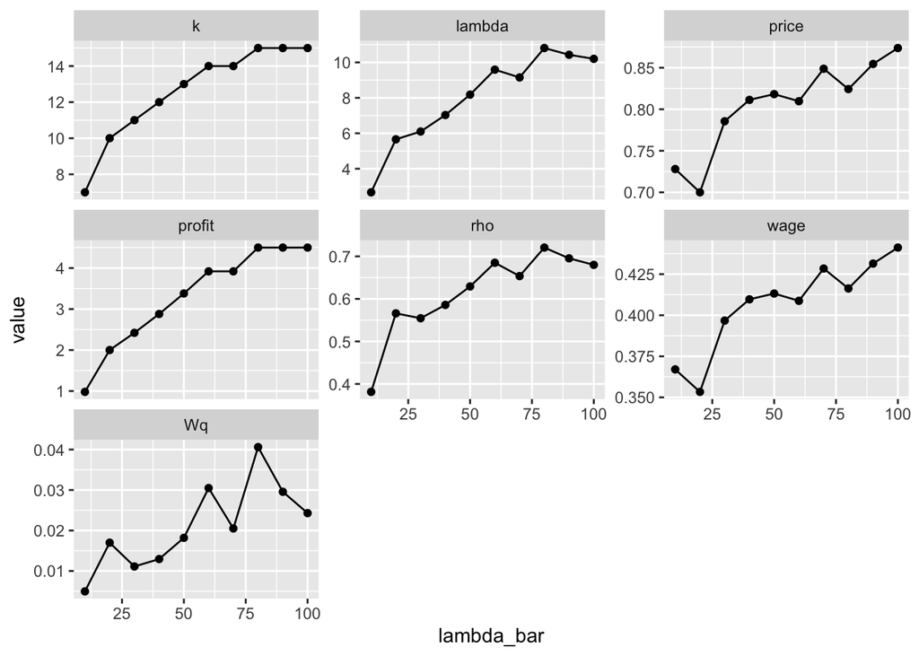

```r
res_df |>
  select(k, lambda, lambda_bar, rho, Wq, price, wage, profit) |>
  pivot_longer(-lambda_bar) |>
  ggplot(aes(x = lambda_bar, y = value)) +
  geom_line() +
  geom_point() +
  facet_wrap(~name, scales = "free_y")
```

##### Preferring lower prices

```r
all_res <- list()
i <- 0
for (lambda_bar in seq(10, 100, 10)) {
  i <- i + 1

  res <- find_optimal_k_and_lambda(
    K = 50,
    lambda_bar = lambda_bar,
    c = 1,
    d = 1,
    mu = 1,
    alpha = 0.5,
    prefer_smaller_price = TRUE
  )
  res$queue_len_dist <- NULL
  all_res[[i]] <- res
}

res_df <- do.call(rbind, lapply(all_res, as.data.frame))

res_df
```

| k | K | lambda | lambda_bar | c | d | mu | rho | alpha | Wq | Lq | price | wage | profit | meets_rho_constraint | meets_fixed_payout_constraint |
| --- | --- | --- | --- | --- | --- | --- | --- | --- | --- | --- | --- | --- | --- | --- | --- |
| 7 | 50 | 4.73 | 10 | 1 | 1 | 1 | 0.6757143 | 0.5 | 0.11597809 | 0.5485764 | 0.4110219 | 0.2071882 | 0.98 | TRUE | TRUE |
| 10 | 50 | 7.19 | 20 | 1 | 1 | 1 | 0.7190000 | 0.5 | 0.08966014 | 0.6446564 | 0.5508399 | 0.2781641 | 2.00 | TRUE | TRUE |
| 11 | 50 | 8.69 | 30 | 1 | 1 | 1 | 0.7900000 | 0.5 | 0.15844116 | 1.3768537 | 0.5518922 | 0.2784810 | 2.42 | TRUE | TRUE |
| 12 | 50 | 9.70 | 40 | 1 | 1 | 1 | 0.8083333 | 0.5 | 0.16872386 | 1.6366214 | 0.5887761 | 0.2969072 | 2.88 | TRUE | TRUE |
| 13 | 50 | 10.55 | 50 | 1 | 1 | 1 | 0.8115385 | 0.5 | 0.15427040 | 1.6275527 | 0.6347296 | 0.3203791 | 3.38 | TRUE | TRUE |
| 14 | 50 | 11.21 | 60 | 1 | 1 | 1 | 0.8007143 | 0.5 | 0.12048900 | 1.3506817 | 0.6926777 | 0.3496878 | 3.92 | TRUE | TRUE |
| 14 | 50 | 11.56 | 70 | 1 | 1 | 1 | 0.8257143 | 0.5 | 0.16254247 | 1.8789910 | 0.6723147 | 0.3391003 | 3.92 | TRUE | TRUE |
| 15 | 50 | 12.02 | 80 | 1 | 1 | 1 | 0.8013333 | 0.5 | 0.10813576 | 1.2997918 | 0.7416142 | 0.3743760 | 4.50 | TRUE | TRUE |
| 15 | 50 | 12.34 | 90 | 1 | 1 | 1 | 0.8226667 | 0.5 | 0.14049264 | 1.7336792 | 0.7223962 | 0.3646677 | 4.50 | TRUE | TRUE |
| 15 | 50 | 12.51 | 100 | 1 | 1 | 1 | 0.8340000 | 0.5 | 0.16187478 | 2.0250535 | 0.7130252 | 0.3597122 | 4.50 | TRUE | TRUE |

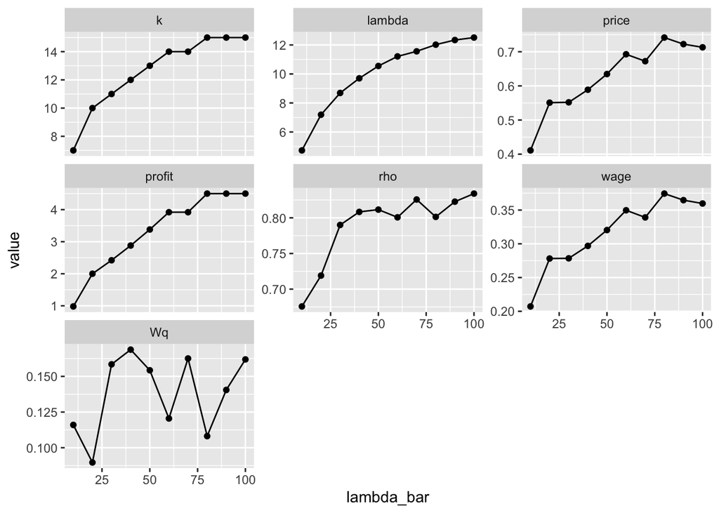

```r
res_df |>
  select(k, lambda, lambda_bar, rho, Wq, price, wage, profit) |>
  pivot_longer(-lambda_bar) |>
  ggplot(aes(x = lambda_bar, y = value)) +
  geom_line() +
  geom_point() +
  facet_wrap(~name, scales = "free_y")
```

#### $d$ - average service units

##### Preferring higher prices

```r
all_res <- list()
i <- 0
for (d in seq(1, 10, 2)) {
  i <- i + 1

  res <- find_optimal_k_and_lambda(
    K = 50,
    lambda_bar = 10,
    c = 1,
    d = d,
    mu = 1,
    alpha = 0.5,
    prefer_smaller_price = FALSE
  )
  res$queue_len_dist <- NULL
  all_res[[i]] <- res
}

res_df <- do.call(rbind, lapply(all_res, as.data.frame))

res_df
```

| k | K | lambda | lambda_bar | c | d | mu | rho | alpha | Wq | Lq | price | wage | profit | meets_rho_constraint | meets_fixed_payout_constraint |
| --- | --- | --- | --- | --- | --- | --- | --- | --- | --- | --- | --- | --- | --- | --- | --- |
| 7 | 50 | 2.67 | 10 | 1 | 1 | 1 | 0.3814286 | 0.5 | 0.004952719 | 0.01322376 | 0.7280473 | 0.3670412 | 0.98 | TRUE | TRUE |
| 11 | 50 | 2.04 | 10 | 1 | 3 | 1 | 0.5563636 | 0.5 | 0.034146398 | 0.06965865 | 0.7846179 | 0.3954248 | 2.42 | TRUE | TRUE |
| 13 | 50 | 1.64 | 10 | 1 | 5 | 1 | 0.6307692 | 0.5 | 0.092759126 | 0.15212497 | 0.8174482 | 0.4121951 | 3.38 | TRUE | TRUE |
| 14 | 50 | 1.31 | 10 | 1 | 7 | 1 | 0.6550000 | 0.5 | 0.146197683 | 0.19151896 | 0.8481146 | 0.4274809 | 3.92 | TRUE | TRUE |
| 15 | 50 | 1.16 | 10 | 1 | 9 | 1 | 0.6960000 | 0.5 | 0.268369460 | 0.31130857 | 0.8541812 | 0.4310345 | 4.50 | TRUE | TRUE |

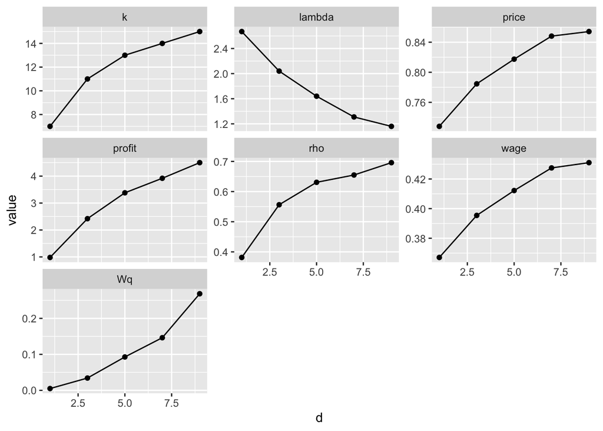

```r
res_df |>
  select(k, lambda, d, rho, Wq, price, wage, profit) |>
  pivot_longer(-d) |>
  ggplot(aes(x = d, y = value)) +
  geom_line() +
  geom_point() +
  facet_wrap(~name, scales = "free_y")
```

##### Preferring lower prices

```r
all_res <- list()
i <- 0
for (d in seq(1, 10, 2)) {
  i <- i + 1

  res <- find_optimal_k_and_lambda(
    K = 50,
    lambda_bar = 10,
    c = 1,
    d = d,
    mu = 1,
    alpha = 0.5,
    prefer_smaller_price = TRUE
  )
  res$queue_len_dist <- NULL
  all_res[[i]] <- res
}

res_df <- do.call(rbind, lapply(all_res, as.data.frame))

res_df
```

| k | K | lambda | lambda_bar | c | d | mu | rho | alpha | Wq | Lq | price | wage | profit | meets_rho_constraint | meets_fixed_payout_constraint |
| --- | --- | --- | --- | --- | --- | --- | --- | --- | --- | --- | --- | --- | --- | --- | --- |
| 7 | 50 | 4.73 | 10 | 1 | 1 | 1 | 0.6757143 | 0.5 | 0.1159781 | 0.5485764 | 0.4110219 | 0.2071882 | 0.98 | TRUE | TRUE |
| 11 | 50 | 2.89 | 10 | 1 | 3 | 1 | 0.7881818 | 0.5 | 0.4661683 | 1.3472263 | 0.5556106 | 0.2791234 | 2.42 | TRUE | TRUE |
| 13 | 50 | 2.11 | 10 | 1 | 5 | 1 | 0.8115385 | 0.5 | 0.7713520 | 1.6275527 | 0.6347296 | 0.3203791 | 3.38 | TRUE | TRUE |
| 14 | 50 | 1.65 | 10 | 1 | 7 | 1 | 0.8250000 | 0.5 | 1.1279667 | 1.8611451 | 0.6738619 | 0.3393939 | 3.92 | TRUE | TRUE |
| 15 | 50 | 1.37 | 10 | 1 | 9 | 1 | 0.8220000 | 0.5 | 1.2540249 | 1.7180141 | 0.7236639 | 0.3649635 | 4.50 | TRUE | TRUE |

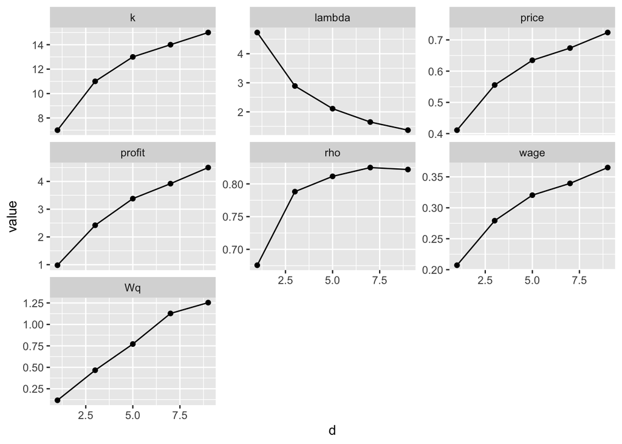

```r
res_df |>
  select(k, lambda, d, rho, Wq, price, wage, profit) |>
  pivot_longer(-d) |>
  ggplot(aes(x = d, y = value)) +
  geom_line() +
  geom_point() +
  facet_wrap(~name, scales = "free_y")
```

#### Allowing non-integer $k$

##### $\alpha$

```r
all_res <- list()
i <- 0
for (alpha in seq(0.1, 0.9, 0.1)) {
  i <- i + 1

  res <- find_optimal_k_and_lambda(
    K = 50,
    lambda_bar = 20,
    c = 1,
    d = 1,
    mu = 1,
    alpha = alpha,
    k_step = 0.2,
    lambda_step = 0.2,
    prefer_smaller_price = FALSE
  )
  res$queue_len_dist <- NULL
  all_res[[i]] <- res
}

res_df <- do.call(rbind, lapply(all_res, as.data.frame))

res_df
```

| k | K | lambda | lambda_bar | c | d | mu | rho | alpha | Wq | Lq | price | wage | profit | meets_rho_constraint | meets_fixed_payout_constraint |
| --- | --- | --- | --- | --- | --- | --- | --- | --- | --- | --- | --- | --- | --- | --- | --- |
| 4.2 | 50 | 2.4 | 20 | 1 | 1 | 1 | 0.5714286 | 0.2 | 0.137781297 | 0.33067511 | 0.7422187 | 0.1470000 | 1.4112000 | TRUE | TRUE |
| 6.6 | 50 | 4.0 | 20 | 1 | 1 | 1 | 0.6060606 | 0.3 | 0.075672400 | 0.30268960 | 0.7243276 | 0.2178000 | 2.0328000 | TRUE | TRUE |
| 8.6 | 50 | 5.4 | 20 | 1 | 1 | 1 | 0.6279070 | 0.4 | 0.051558138 | 0.27841395 | 0.6784419 | 0.2739259 | 2.2188000 | TRUE | TRUE |
| 10.2 | 50 | 6.4 | 20 | 1 | 1 | 1 | 0.6274510 | 0.5 | 0.033245952 | 0.21277409 | 0.6467540 | 0.3251250 | 2.0808000 | TRUE | TRUE |
| 11.6 | 50 | 7.2 | 20 | 1 | 1 | 1 | 0.6206897 | 0.6 | 0.022787841 | 0.16407245 | 0.6172122 | 0.3737778 | 1.7941333 | TRUE | TRUE |
| 12.8 | 50 | 7.8 | 20 | 1 | 1 | 1 | 0.6093750 | 0.7 | 0.015212298 | 0.11865593 | 0.5947877 | 0.4201026 | 1.4043429 | TRUE | TRUE |
| 13.8 | 50 | 8.0 | 20 | 1 | 1 | 1 | 0.5797101 | 0.8 | 0.007956134 | 0.06364908 | 0.5920439 | 0.4761000 | 0.9522000 | TRUE | TRUE |
| 14.8 | 50 | 8.4 | 20 | 1 | 1 | 1 | 0.5675676 | 0.9 | 0.005207442 | 0.04374251 | 0.5747926 | 0.5215238 | 0.4867556 | TRUE | TRUE |

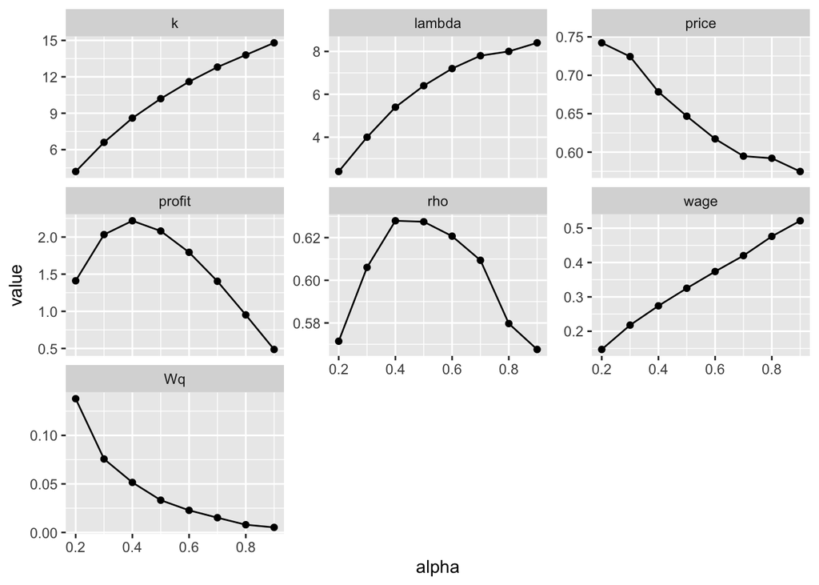

```r
res_df |>
  select(k, lambda, rho, alpha, Wq, price, wage, profit) |>
  pivot_longer(-alpha) |>
  ggplot(aes(x = alpha, y = value)) +
  geom_line() +
  geom_point() +
  facet_wrap(~name, scales = "free_y")
```

##### $\bar{\lambda}$

```r
all_res <- list()
i <- 0
for (lambda_bar in seq(10, 100, 10)) {
  i <- i + 1

  res <- find_optimal_k_and_lambda(
    K = 50,
    lambda_bar = lambda_bar,
    c = 1,
    d = 1,
    mu = 1,
    alpha = 0.5,
    k_step = 0.2,
    lambda_step = 0.2,
    prefer_smaller_price = FALSE
  )
  res$queue_len_dist <- NULL
  all_res[[i]] <- res
}

res_df <- do.call(rbind, lapply(all_res, as.data.frame))

res_df
```

| k | K | lambda | lambda_bar | c | d | mu | rho | alpha | Wq | Lq | price | wage | profit | meets_rho_constraint | meets_fixed_payout_constraint |
| --- | --- | --- | --- | --- | --- | --- | --- | --- | --- | --- | --- | --- | --- | --- | --- |
| 7.6 | 50 | 3.8 | 10 | 1 | 1 | 1 | 0.5000000 | 0.5 | 0.01780114 | 0.06764433 | 0.6021989 | 0.3040000 | 1.1552 | TRUE | TRUE |
| 10.2 | 50 | 6.4 | 20 | 1 | 1 | 1 | 0.6274510 | 0.5 | 0.03324595 | 0.21277409 | 0.6467540 | 0.3251250 | 2.0808 | TRUE | TRUE |
| 11.8 | 50 | 8.0 | 30 | 1 | 1 | 1 | 0.6779661 | 0.5 | 0.04385249 | 0.35081995 | 0.6894808 | 0.3481000 | 2.7848 | TRUE | TRUE |
| 12.8 | 50 | 8.8 | 40 | 1 | 1 | 1 | 0.6875000 | 0.5 | 0.04071690 | 0.35830873 | 0.7392831 | 0.3723636 | 3.2768 | TRUE | TRUE |
| 13.6 | 50 | 9.6 | 50 | 1 | 1 | 1 | 0.7058824 | 0.5 | 0.04361282 | 0.41868303 | 0.7643872 | 0.3853333 | 3.6992 | TRUE | TRUE |
| 14.2 | 50 | 10.2 | 60 | 1 | 1 | 1 | 0.7183099 | 0.5 | 0.04488589 | 0.45783604 | 0.7851141 | 0.3953725 | 4.0328 | TRUE | TRUE |
| 14.6 | 50 | 10.6 | 70 | 1 | 1 | 1 | 0.7260274 | 0.5 | 0.04778378 | 0.50650811 | 0.8007876 | 0.4021887 | 4.2632 | TRUE | TRUE |
| 15.0 | 50 | 11.0 | 80 | 1 | 1 | 1 | 0.7333333 | 0.5 | 0.04744986 | 0.52194845 | 0.8150501 | 0.4090909 | 4.5000 | TRUE | TRUE |
| 15.4 | 50 | 11.6 | 90 | 1 | 1 | 1 | 0.7532468 | 0.5 | 0.05899557 | 0.68434856 | 0.8121155 | 0.4088966 | 4.7432 | TRUE | TRUE |
| 15.6 | 50 | 11.6 | 100 | 1 | 1 | 1 | 0.7435897 | 0.5 | 0.05170542 | 0.59978293 | 0.8322946 | 0.4195862 | 4.8672 | TRUE | TRUE |

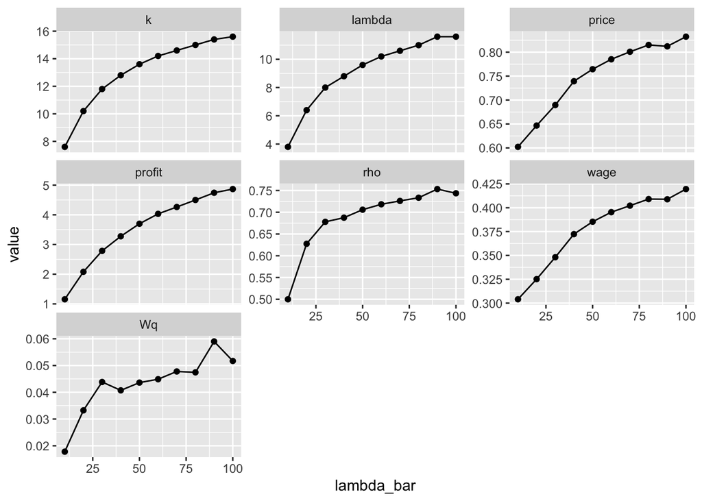

```r
res_df |>
  select(k, lambda, lambda_bar, rho, Wq, price, wage, profit) |>
  pivot_longer(-lambda_bar) |>
  ggplot(aes(x = lambda_bar, y = value)) +
  geom_line() +
  geom_point() +
  facet_wrap(~name, scales = "free_y")
```

### An approximation scheme

- To approximate and give tractable analytical results can instead be approximated with $W_q = \frac{ \rho ^ \sqrt{2 (k + 1)} }{ \lambda (1 - \rho) }$
  - The approximation formula is exact for an $M/M/1$ queue (i.e. plug $k = 1$ into above complex form and it reduces to $W_q = \frac{ \rho ^ 2 }{ \lambda (1 - \rho) } = \frac{ \rho ^ \sqrt{2 (k + 1)} }{ \lambda (1 - \rho) }$ )
  - The approximation has been shown (see Sakasegawa 1977) to provide a very good estimate when $k > 1$ .

See below for how this approximation compares to more exact, but more unwieldy formulation.

The paper actually goes further from exact calc and rewrites to be $W_q = \frac{ \rho ^ \sqrt{2 (n + 1)} }{ \lambda (1 - \rho) }$. And $n$ is set to be $k^*$. This means for $k^*$, $W_q$ is well approximated, but for values of $k < k^*$ the $W_q$ will be over estimated and for values of $k > k^*$, $W_q$ will be underestimated.

```r
approx_wait_time_ <- function(k, lambda, mu, d) {
  # $$
  # W_q = \frac{ \rho ^ \sqrt{2 (k + 1)} }{ \lambda (1 - \rho) }
  # $$

  # Calculate rho (system utilization)
  rho <- (lambda * d) / (k * mu)

  # numerator shows traffic intensity - for large k, less sensitive to traffic
  # denominator combines arrival rate and idle capacity
  # to show traffic that can be handled without queueing
  wait_time <- (rho^sqrt(2 * (k + 1))) / (lambda * (1 - rho))
  return(wait_time)
}

approx_wait_time <- Vectorize(approx_wait_time_, c("k", "lambda", "mu", "d"))
```

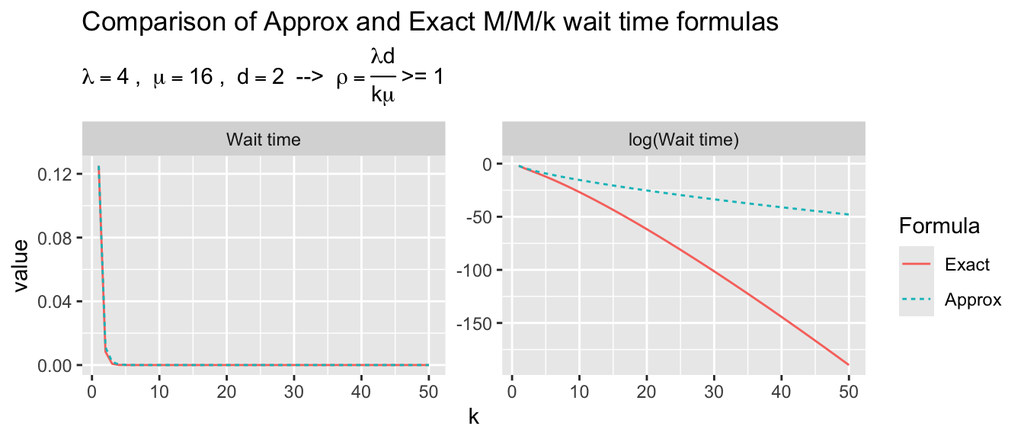

```r
k <- 1:50

lambda <- 4
mu <- 16
d <- 2

wait_time_compare <- data.frame(
  k = k,
  Exact = exact_wait_time(k, lambda, mu, d),
  Approx = approx_wait_time(k, lambda, mu, d)
) |>
  pivot_longer(-k, names_to = "Formula") |>
  mutate(`log(Wait time)` = log(value)) |>
  rename(`Wait time` = value) |>
  pivot_longer(contains("Wait"), names_to = "trans") |>
  mutate(trans = forcats::fct_rev(trans), Formula = forcats::fct_rev(Formula))

ggplot(wait_time_compare, aes(x = k, y = value, color = Formula, linetype = Formula)) +
  geom_line() +
  facet_wrap(~trans, scales = "free_y") +
  labs(
    title = "Comparison of Approx and Exact M/M/k wait time formulas",
    subtitle = bquote(lambda == .(lambda) ~ ", " ~
      mu == .(mu) ~ ", " ~
      d == .(d) ~ " --> " ~
      rho == frac(lambda * d, k * mu) ~ ">=" ~ 1)
  )
```

# Slides

[figure not shown]